# Nutrient hotspot maps — post-Kona low storm

# Salinity-based enrichment above marine background

Within the same sampling event, sites with salinity above 34 PSU were minimally affected by freshwater runoff — they represent what the ocean chemistry looked like without the storm signal. Comparing these 320 “background” sites to the 241 most storm-influenced sites (Sal < 32 PSU) gives a direct, within-study measure of how much the storm changed things.

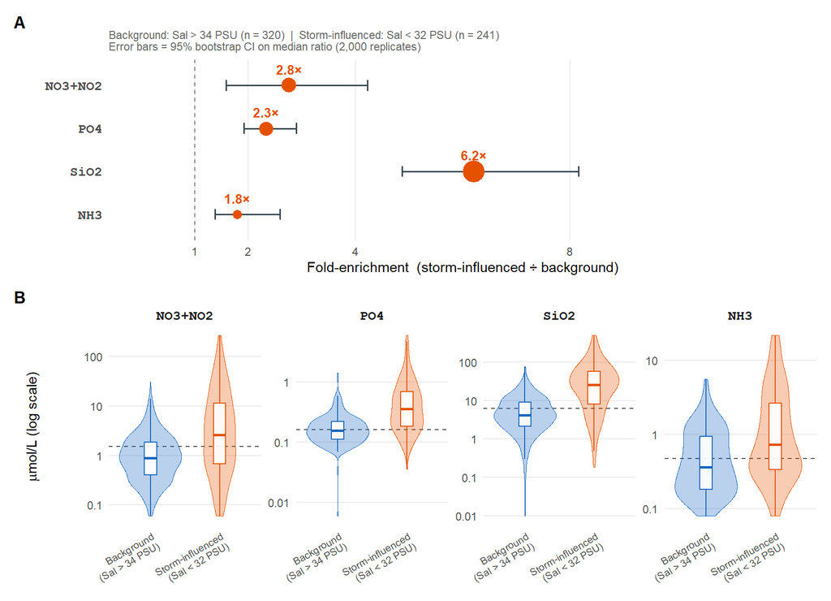

How much higher were nutrient levels in storm-influenced water compared to clean marine water sampled at the same time? (A) The fold-enrichment for each nutrient — how many times higher the typical storm-influenced concentration was relative to the marine background. Point size reflects the magnitude; error bars are 95% confidence intervals from 2,000 bootstrap resamples. SiO₂ was 6× higher, consistent with volcanic rock dissolving in freshwater and flowing into the coast. NO₃+NO₂ was 3× higher and PO₄ was about 2.3× higher, reflecting runoff from farms, cesspools, and soils. NH₃ was 2× higher but more variable, consistent with it coming partly from runoff and partly from biological processes. (B) The full distribution of concentrations in each zone. Dashed lines show the background zone means.

```r
# ── Define salinity zones ────────────────────────────────────────────────────
sal_zones <- chem |>
  filter(!is.na(Salinity)) |>
  mutate(zone = case_when(
    Salinity > 34.0 ~ "Background\n(Sal > 34 PSU)",
    Salinity < 32.0 ~ "Storm-influenced\n(Sal < 32 PSU)",
    TRUE            ~ NA_character_
  )) |>
  filter(!is.na(zone))

bg   <- sal_zones |> filter(str_detect(zone, "Background"))
strm <- sal_zones |> filter(str_detect(zone, "Storm"))

nutrients_vec    <- c("NO3NO2", "PO4", "SiO2", "NH3")
nut_labels_ascii <- c("NO3+NO2", "PO4", "SiO2", "NH3")
zone_pal <- c(
  "Background\n(Sal > 34 PSU)"       = "#1565C0",
  "Storm-influenced\n(Sal < 32 PSU)" = "#E65100"
)

# ── Bootstrap fold-changes ───────────────────────────────────────────────────
set.seed(4492)
ci_df <- map_dfr(seq_along(nutrients_vec), function(i) {
  nut  <- nutrients_vec[i]
  bg_v <- bg[[nut]];   bg_v <- bg_v[!is.na(bg_v)]
  st_v <- strm[[nut]]; st_v <- st_v[!is.na(st_v)]
  boot <- replicate(2000, {
    median(sample(st_v, replace = TRUE)) /
    median(sample(bg_v, replace = TRUE))
  })
  tibble(
    nutrient  = nut_labels_ascii[i],
    fold      = median(st_v) / median(bg_v),
    lo        = quantile(boot, 0.025),
    hi        = quantile(boot, 0.975)
  )
}) |>
  mutate(nutrient = factor(nutrient, levels = rev(nut_labels_ascii)))

# ── Panel A: fold-change ─────────────────────────────────────────────────────
pFold <- ggplot(ci_df, aes(x = fold, y = nutrient)) +
  geom_vline(xintercept = 1, linetype = "dashed",
             color = "gray50", linewidth = 0.5) +
  geom_errorbar(aes(xmin = lo, xmax = hi),
                width = 0.25, linewidth = 0.6,
                color = "#37474F", orientation = "y") +
  geom_point(aes(size = fold), color = "#E65100", shape = 16) +
  geom_text(aes(label = paste0(round(fold, 1), "×")),
            nudge_y = 0.38, size = 3.5, fontface = "bold",
            color = "#E65100") +
  scale_x_continuous(limits = c(0, 12), breaks = c(1, 2, 4, 8)) +
  scale_size_continuous(range = c(3, 8), guide = "none") +
  labs(
    x        = "Fold-enrichment  (storm-influenced ÷ background)",
    y        = NULL, tag = "A",
    subtitle = paste0(
      "Background: Sal > 34 PSU (n = ", nrow(bg),
      ")  |  Storm-influenced: Sal < 32 PSU (n = ", nrow(strm), ")\n",
      "Error bars = 95% bootstrap CI on median ratio (2,000 replicates)"
    )
  ) +
  theme_minimal(base_size = 11) +
  theme(panel.grid.minor    = element_blank(),
        panel.grid.major.y  = element_blank(),
        axis.text.y  = element_text(size = 10.5, face = "bold",
                                    family = "mono"),
        plot.subtitle = element_text(size = 8.5, color = "gray40"),
        plot.tag      = element_text(face = "bold"))

# ── Panel B: distributions ───────────────────────────────────────────────────
nut_long_zones <- sal_zones |>
  select(zone, all_of(nutrients_vec)) |>
  pivot_longer(all_of(nutrients_vec),
               names_to = "nutrient", values_to = "conc") |>
  filter(!is.na(conc), conc > 0) |>
  mutate(
    nutrient = factor(recode(nutrient,
      "NO3NO2" = "NO3+NO2", "PO4" = "PO4",
      "SiO2"   = "SiO2",    "NH3" = "NH3"),
      levels = nut_labels_ascii),
    zone = factor(zone, levels = names(zone_pal))
  )

bg_means <- bg |>
  summarise(across(all_of(nutrients_vec), \(x) mean(x, na.rm = TRUE))) |>
  pivot_longer(everything(), names_to = "nutrient", values_to = "bg_mean") |>
  mutate(nutrient = factor(recode(nutrient,
    "NO3NO2" = "NO3+NO2", "PO4" = "PO4", "SiO2" = "SiO2", "NH3" = "NH3"),
    levels = nut_labels_ascii))

pDist <- ggplot(nut_long_zones,
                aes(x = zone, y = conc, fill = zone, color = zone)) +
  geom_hline(data = bg_means, aes(yintercept = bg_mean),
             linetype = "dashed", color = "gray30",
             linewidth = 0.5, inherit.aes = FALSE) +
  geom_violin(alpha = 0.30, linewidth = 0.3, trim = TRUE) +
  geom_boxplot(width = 0.18, outliers = FALSE,
               fill = "white", linewidth = 0.45, alpha = 0.9) +
  scale_fill_manual(values  = zone_pal) +
  scale_color_manual(values = zone_pal) +
  scale_y_log10(labels = scales::label_number(drop0trailing = TRUE)) +
  facet_wrap(~nutrient, nrow = 1, scales = "free_y") +
  labs(x = NULL, y = expression(mu*"mol/L (log scale)"), tag = "B") +
  theme_minimal(base_size = 11) +
  theme(panel.grid.minor    = element_blank(),
        panel.grid.major.x  = element_blank(),
        axis.text.x  = element_text(angle = 30, hjust = 1, size = 8),
        strip.text   = element_text(face = "bold", size = 10.5,
                                    family = "mono"),
        legend.position = "none",
        plot.tag     = element_text(face = "bold"))

pFold / pDist + plot_layout(heights = c(1, 1.1))
```

```r
ggsave(here("output","nutrients_by_salinity.png"), width = 8, height = 6)
```

**Bottom line:** storm-influenced coastal water had silica levels 6× higher, nitrogen 3× higher, and phosphorus 2.3× higher than clean marine water sampled at the same time.